# Mon rapport sur la profondeur des séismes

Auteur·rice

Julianne Fréchette, IDUL: JUFRE48

## Question et données

La question est: comment les événements de ce tableau se répartissent-ils entre les profondeurs inférieures à 300 km et les profondeurs de 300 km ou plus?

L’unité d’observation est les séismes. La variable est la profondeur en km.

## Préparation

Le jeu de données est séparé en 2 classes: les séismes avec une profondeur de moins de 300 km et les séismes de 300 km ou plus. Les contrôles vérifient que la somme des effectifs des classes est égale au nombre total de séismes. Ils vérifient également que la somme des proportions de chaque classe est égale à 1.

## Tableau

**Afficher le code**

```r
kable(repartition_profondeur, digits = 1)
```

Tableau 1: Effectifs par classe de profondeur

| classe_profondeur | effectif | proportion |
| --- | --- | --- |
| Moins de 300 km | 547 | 0.5 |
| 300 km ou plus | 453 | 0.5 |

## Figure

La figure 1 représente les effectifs du tableau 1.

**Afficher le code**

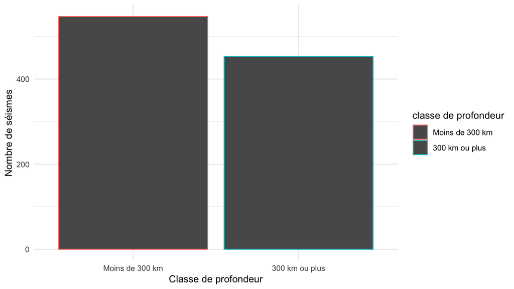

Figure 1: Effectifs par classe de profondeur

```r
ggplot(repartition_profondeur, aes(
  x = classe_profondeur,
  y = effectif,
  colour = classe_profondeur)) +
  geom_col() +
  labs(x = "Classe de profondeur", y = "Nombre de séismes", colour="classe de profondeur") +
  theme_minimal()
```

## Interprétation et limite

Les séismes avec une profondeur de moins de 300 km représentent 54.7 % des séismes. Il n’est pas possible de calculer un nombre annuel de séismes avec ce fichier, car il ne contient pas les dates des séismes.

## Reproduction

Pour refaire ce rapport, conserver le fichier `.qmd` et le dossier `donnees/` ensemble. Les bibliothèques utilisées sont `readr`, `dplyr`, `ggplot2` et `knitr`.

```
quarto render rapport.qmd
```

À compléter : indiquer la vérification réalisée depuis une session propre et depuis une copie du dossier. Pour vérifier que le rapport fonctionne, la session R a été redémarrée et le rendu a été refait. De plus, ce document et les données ont été copiées dans un autre répertoire, et le rendu a été refait. Dans les deux cas, le rapport HTML contenait tous les éléments.